# lesson3_problems

## Load diamonds data set

```r
setwd("/Users/brianchase/R")
library(ggplot2)
data(diamonds)

summary(diamonds)
```

```
##      carat               cut        color        clarity
##  Min.   :0.2000   Fair     : 1610   D: 6775   SI1    :13065
##  1st Qu.:0.4000   Good     : 4906   E: 9797   VS2    :12258
##  Median :0.7000   Very Good:12082   F: 9542   SI2    : 9194
##  Mean   :0.7979   Premium  :13791   G:11292   VS1    : 8171
##  3rd Qu.:1.0400   Ideal    :21551   H: 8304   VVS2   : 5066
##  Max.   :5.0100                     I: 5422   VVS1   : 3655
##                                     J: 2808   (Other): 2531
##      depth           table           price             x
##  Min.   :43.00   Min.   :43.00   Min.   :  326   Min.   : 0.000
##  1st Qu.:61.00   1st Qu.:56.00   1st Qu.:  950   1st Qu.: 4.710
##  Median :61.80   Median :57.00   Median : 2401   Median : 5.700
##  Mean   :61.75   Mean   :57.46   Mean   : 3933   Mean   : 5.731
##  3rd Qu.:62.50   3rd Qu.:59.00   3rd Qu.: 5324   3rd Qu.: 6.540
##  Max.   :79.00   Max.   :95.00   Max.   :18823   Max.   :10.740
##
##        y                z
##  Min.   : 0.000   Min.   : 0.000
##  1st Qu.: 4.720   1st Qu.: 2.910
##  Median : 5.710   Median : 3.530
##  Mean   : 5.735   Mean   : 3.539
##  3rd Qu.: 6.540   3rd Qu.: 4.040
##  Max.   :58.900   Max.   :31.800
##
```

```r
?diamonds
```

## Create a histogram of the price of

## all the diamonds in the diamond data set.

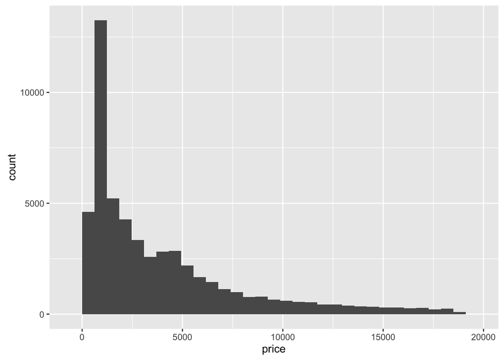

```r
qplot(x = price, data = diamonds)
```

## Describe shape and center. include summary statistics like mean and median.

```r
summary(diamonds$price)
```

```
##    Min. 1st Qu.  Median    Mean 3rd Qu.    Max.
##     326     950    2401    3933    5324   18820
```

## DIamond counts

How many diamonds cost less than $500

```r
sum(diamonds$price < 500)
```

```
## [1] 1729
```

How many diamonds cost less than $250

```r
sum(diamonds$price < 250)
```

```
## [1] 0
```

How many diamonds cost more than $15000

```r
sum(diamonds$price >= 15000)
```

```
## [1] 1656
```

## Exploring the largest peak in the price histogram

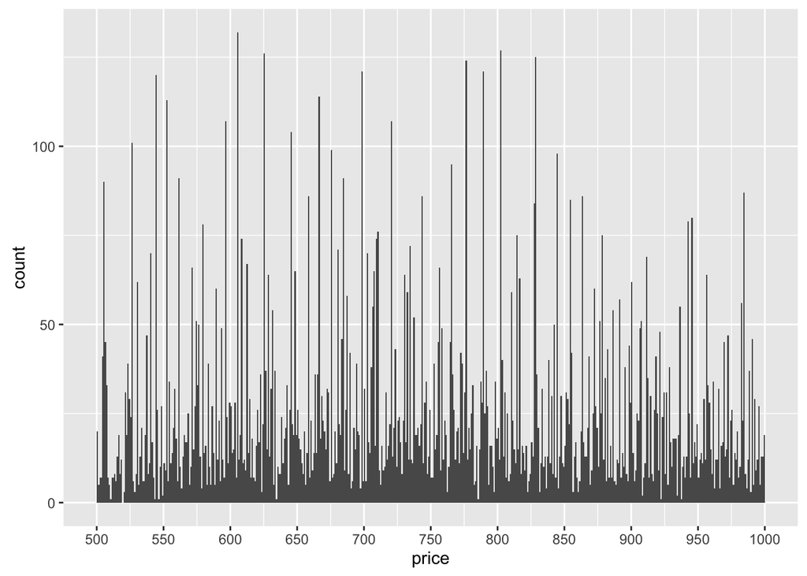

```r
qplot(x = price, data = diamonds, binwidth=1) +
  scale_x_continuous(limits = c(500, 1000), breaks =seq(500,1000,50))
```

```r
sum(diamonds$price == 605)
```

```
## [1] 132
```

## Price by Cut histograms (use multiple panels)

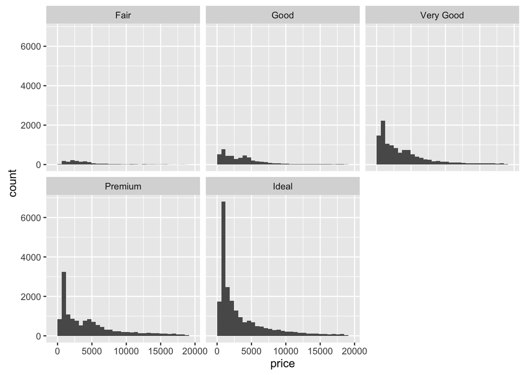

```r
qplot(x = price, data = diamonds) +
  facet_wrap(~cut)
```

## Finding lowest, highest, lowest median price based on cut

```r
by(diamonds$price, diamonds$cut, min)
```

```
## diamonds$cut: Fair
## [1] 337
## --------------------------------------------------------
## diamonds$cut: Good
## [1] 327
## --------------------------------------------------------
## diamonds$cut: Very Good
## [1] 336
## --------------------------------------------------------
## diamonds$cut: Premium
## [1] 326
## --------------------------------------------------------
## diamonds$cut: Ideal
## [1] 326
```

```r
by(diamonds$price, diamonds$cut, max)
```

```
## diamonds$cut: Fair
## [1] 18574
## --------------------------------------------------------
## diamonds$cut: Good
## [1] 18788
## --------------------------------------------------------
## diamonds$cut: Very Good
## [1] 18818
## --------------------------------------------------------
## diamonds$cut: Premium
## [1] 18823
## --------------------------------------------------------
## diamonds$cut: Ideal
## [1] 18806
```

```r
by(diamonds$price, diamonds$cut, median)
```

```
## diamonds$cut: Fair
## [1] 3282
## --------------------------------------------------------
## diamonds$cut: Good
## [1] 3050.5
## --------------------------------------------------------
## diamonds$cut: Very Good
## [1] 2648
## --------------------------------------------------------
## diamonds$cut: Premium
## [1] 3185
## --------------------------------------------------------
## diamonds$cut: Ideal
## [1] 1810
```

## histograms with different ranges in y axis (This shows that fair and good are similar distributions)

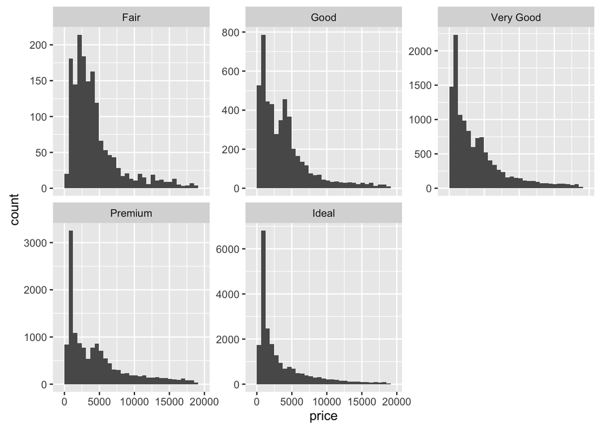

```r
qplot(x = price, data = diamonds) +
  facet_wrap(~cut, scales="free_y")
```

## Price per carat cut

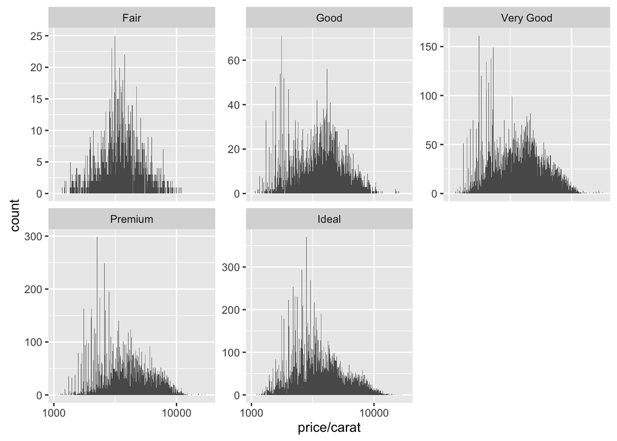

```r
qplot(x = price/carat, data = diamonds, bins=500) +
  facet_wrap(~cut, scales="free_y") +
  scale_x_log10()
```

## Investigate by color with box plot and summary

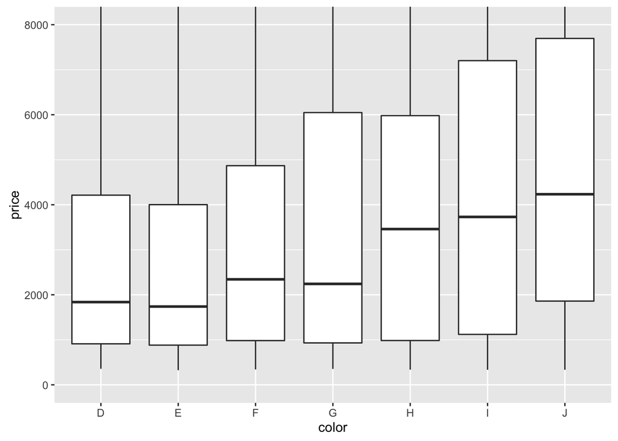

```r
qplot(x = color, y = price,
      data = diamonds,
      geom = 'boxplot') +
  coord_cartesian(ylim = c(0, 8000))
```

```r
by(diamonds$price, diamonds$color, summary)
```

```
## diamonds$color: D
##    Min. 1st Qu.  Median    Mean 3rd Qu.    Max.
##     357     911    1838    3170    4214   18690
## --------------------------------------------------------
## diamonds$color: E
##    Min. 1st Qu.  Median    Mean 3rd Qu.    Max.
##     326     882    1739    3077    4003   18730
## --------------------------------------------------------
## diamonds$color: F
##    Min. 1st Qu.  Median    Mean 3rd Qu.    Max.
##     342     982    2344    3725    4868   18790
## --------------------------------------------------------
## diamonds$color: G
##    Min. 1st Qu.  Median    Mean 3rd Qu.    Max.
##     354     931    2242    3999    6048   18820
## --------------------------------------------------------
## diamonds$color: H
##    Min. 1st Qu.  Median    Mean 3rd Qu.    Max.
##     337     984    3460    4487    5980   18800
## --------------------------------------------------------
## diamonds$color: I
##    Min. 1st Qu.  Median    Mean 3rd Qu.    Max.
##     334    1120    3730    5092    7202   18820
## --------------------------------------------------------
## diamonds$color: J
##    Min. 1st Qu.  Median    Mean 3rd Qu.    Max.
##     335    1860    4234    5324    7695   18710
```

What is the price range for the moiddle 50% of diamonds (color D)? first quartile? 911 third quartile? 4214 Same foar color J: first quartile? 1860 third quartile? 7695

What is IQR? Q3 - Q1

3. IQR D color: 4214-911 = 3,303
4. IQR J color: 7695-1860 = 5,835

## Price per carat across different colors box plot

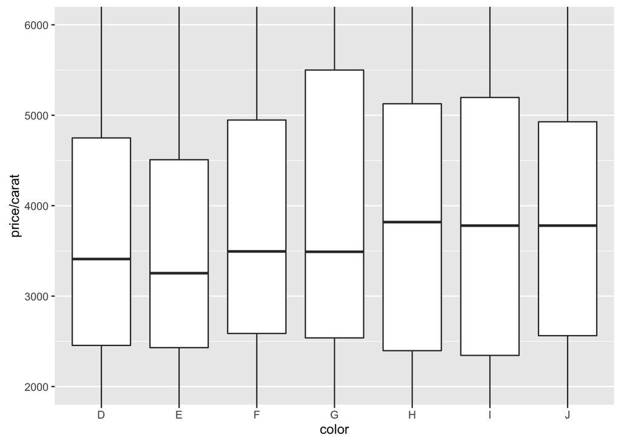

```r
qplot(x = color, y = price/carat,
      data = diamonds,
      geom = 'boxplot') +
  coord_cartesian(ylim = c(2000, 6000))
```

```r
by(diamonds$price / diamonds$carat, diamonds$color, summary)
```

```
## diamonds$color: D
##    Min. 1st Qu.  Median    Mean 3rd Qu.    Max.
##    1128    2455    3411    3953    4749   17830
## --------------------------------------------------------
## diamonds$color: E
##    Min. 1st Qu.  Median    Mean 3rd Qu.    Max.
##    1078    2430    3254    3805    4508   14610
## --------------------------------------------------------
## diamonds$color: F
##    Min. 1st Qu.  Median    Mean 3rd Qu.    Max.
##    1168    2587    3494    4135    4947   13860
## --------------------------------------------------------
## diamonds$color: G
##    Min. 1st Qu.  Median    Mean 3rd Qu.    Max.
##    1139    2538    3490    4163    5500   12460
## --------------------------------------------------------
## diamonds$color: H
##    Min. 1st Qu.  Median    Mean 3rd Qu.    Max.
##    1051    2397    3819    4008    5127   10190
## --------------------------------------------------------
## diamonds$color: I
##    Min. 1st Qu.  Median    Mean 3rd Qu.    Max.
##    1152    2345    3780    3996    5197    9398
## --------------------------------------------------------
## diamonds$color: J
##    Min. 1st Qu.  Median    Mean 3rd Qu.    Max.
##    1081    2563    3780    3826    4928    8647
```

## Carat Frequenct Polygon : What carat size has a count greater than 2000?

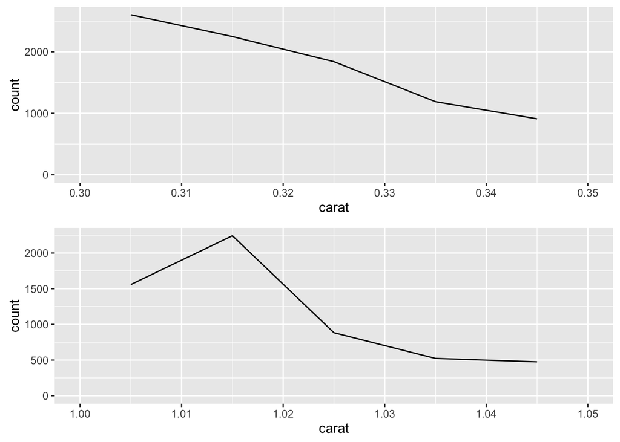

```r
library(gridExtra)

p1 <- qplot(x = carat, data = diamonds, binwidth = 0.01,
      geom = 'freqpoly') +
  scale_x_continuous(limits = c(0.3, 0.35), breaks =seq(0.3,0.35,0.01))

p2 <- qplot(x = carat, data = diamonds, binwidth = 0.01,
      geom = 'freqpoly') +
  scale_x_continuous(limits = c(1, 1.05), breaks =seq(0,1.05,0.01))

grid.arrange(p1,p2, ncol=1)
```

tidyr -a package that reshapes the layout of your data

dplyr - a package that helps you transform tidy, tabular data

[Data wrangling in R presentation](https://s3.amazonaws.com/udacity-hosted-downloads/ud651/DataWranglingWithR.pdf) [Data wrangling cheat sheet](http://www.rstudio.com/wp-content/uploads/2015/02/data-wrangling-cheatsheet.pdf) [other r studio cheat sheets](http://www.rstudio.com/resources/cheatsheets/)

## Load gapminder data on Median Age

```r
age_data <- read.csv('data_median_age.csv')

summary(age_data$X1950)
```

```
##    Min. 1st Qu.  Median    Mean 3rd Qu.    Max.    NA's
##   15.24   19.04   20.72   22.33   24.66   35.72       2
```

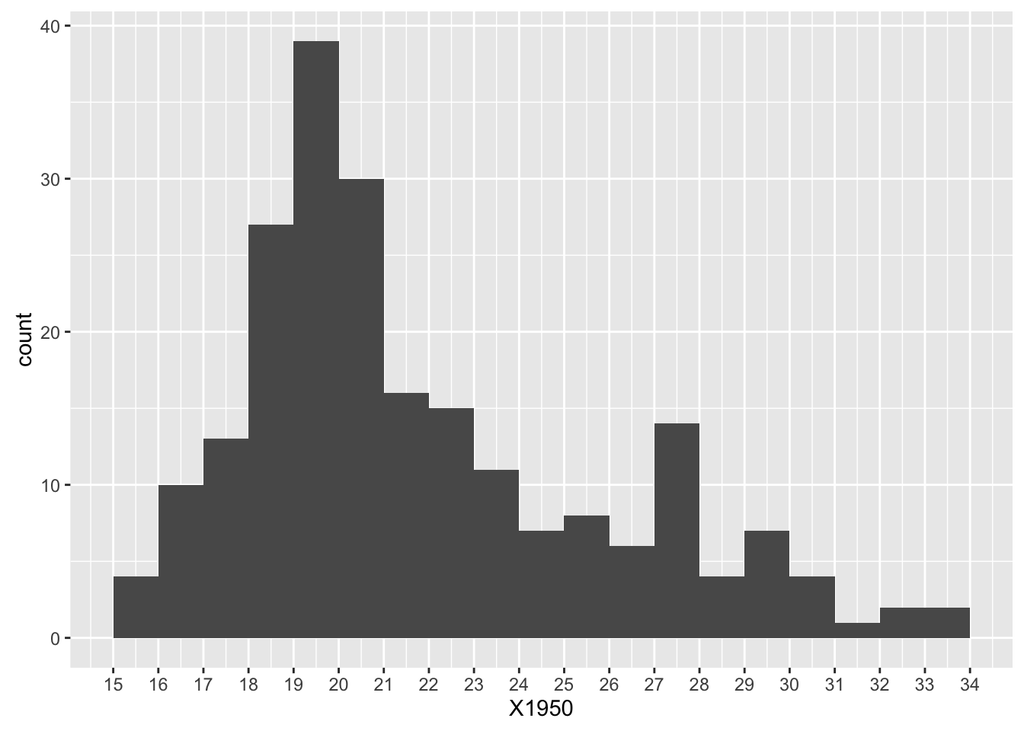

```r
qplot(x = X1950,
      data = age_data, binwidth = 1) +
  scale_x_continuous(limits = c(15, 34), breaks =seq(15,34,1))
```

```r
summary(age_data$X2015)
```

```
##    Min. 1st Qu.  Median    Mean 3rd Qu.    Max.    NA's
##   14.84   21.77   28.60   29.53   37.70   46.60       2
```

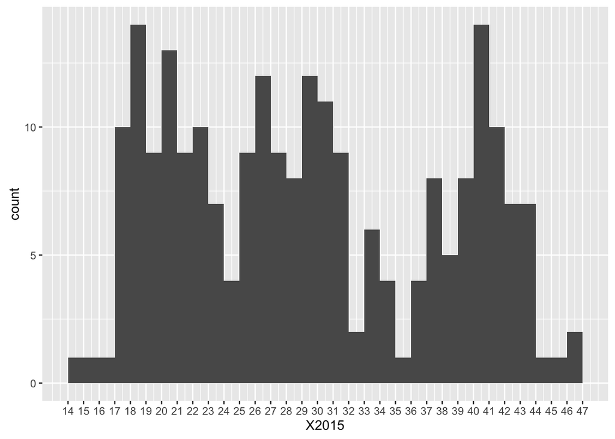

```r
qplot(x = X2015,
      data = age_data, binwidth = 1) +
  scale_x_continuous(limits = c(14, 47), breaks =seq(14,47,1))
```

Loaded data with median ages based on countries and date (dates also include future projections)

Looking at this data, I notice that there are now three group in the histogram (17-23), (25-31), (36-43)

```r
age_data_2015_17to23 <- subset(age_data, age_data$`2015` < 24)
age_data_2015_17to23$`Median age`
```

[output not shown]

```r
age_data_2015_25to31 <- subset(age_data, age_data$`2015` > 25 & age_data$`2015` < 32)
age_data_2015_25to31$`Median age`
```

[output not shown]

```r
age_data_2015_36to43 <- subset(age_data, age_data$`2015` > 35 & age_data$`2015` < 44)
age_data_2015_36to43$`Median age`
```

[output not shown]

Plotting the future projection historgram

```r
summary(age_data$X2050)
```

```
##    Min. 1st Qu.  Median    Mean 3rd Qu.    Max.    NA's
##   20.16   31.70   39.12   38.32   43.86   55.78       2
```

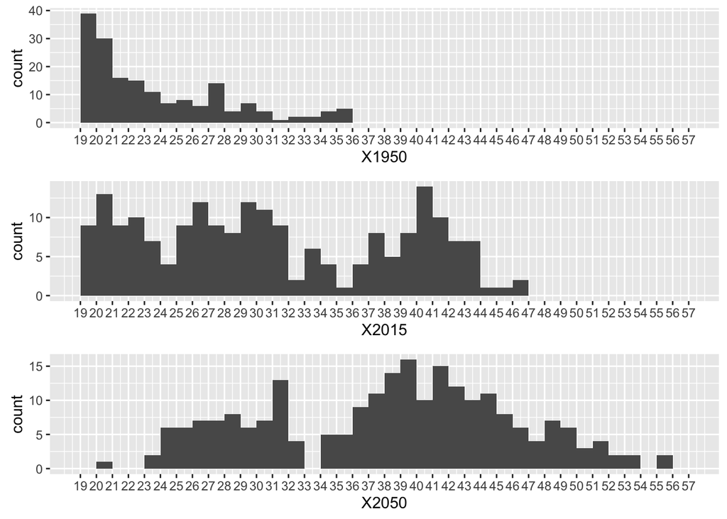

```r
library(gridExtra)


p3 <- qplot(x = `X2050`,
      data = age_data, binwidth = 1) +
  scale_x_continuous(limits = c(19, 57), breaks =seq(19,57,1))

p2 <- qplot(x = `X1950`,
      data = age_data, binwidth = 1) +
  scale_x_continuous(limits = c(19, 57), breaks =seq(19,57,1))

p1 <- qplot(x = `X2015`,
      data = age_data, binwidth = 1) +
  scale_x_continuous(limits = c(19, 57), breaks =seq(19,57,1))

p4 <- grid.arrange(p2, p1, p3, ncol=1)
```

```r
ggsave('median_age_histograms2.png', plot = p4)
```

Finding another chart to make

How do you create a plot with the years on the x axis and the median age on the y axis colored by country?

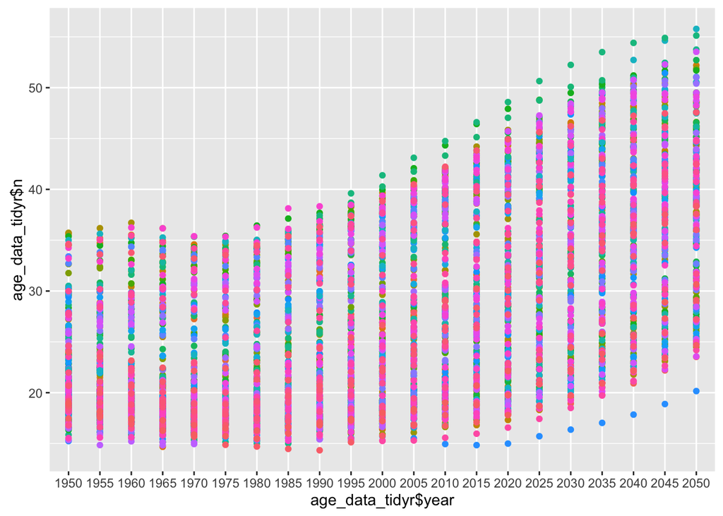

```r
#install.packages('tidyr', dependencies=T)
setwd("/Users/brianchase/R")
age_data <- read.csv('data_median_age.csv',header = T,check.names = F)
library(tidyr)
age_data[23] <- NULL
age_data_tidyr <- gather(age_data, "year", "n", 2:22)

qplot(x=age_data_tidyr$year, y=age_data_tidyr$n, data=age_data_tidyr,
      geom = c('point', 'path'), color=age_data_tidyr$`Median age`) +
  guides(color=FALSE)
```

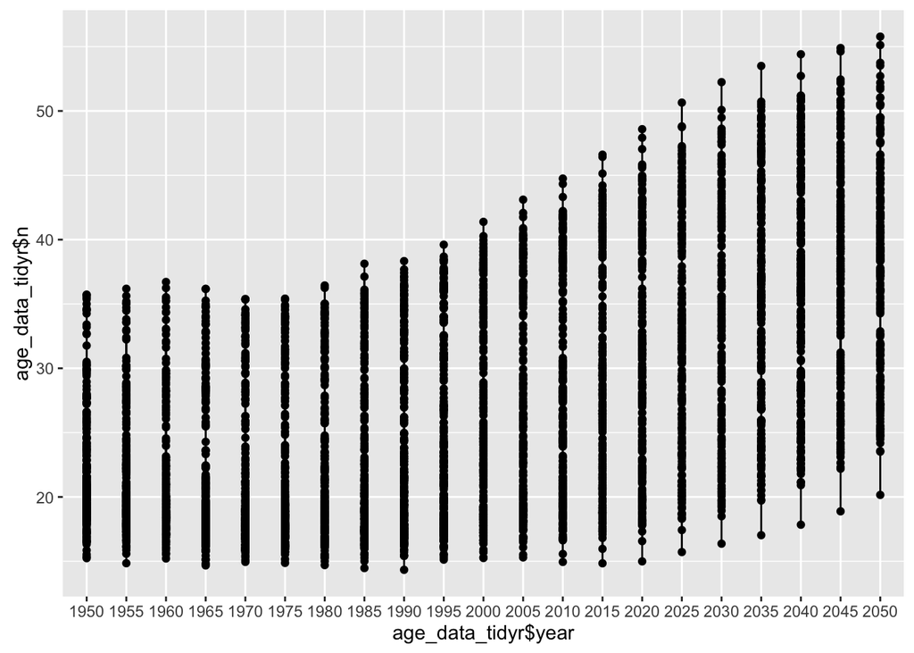

```r
qplot(x=age_data_tidyr$year, y=age_data_tidyr$n, data=age_data_tidyr,
      geom = c('point', 'path'))
```

Problem is that there are just too many countries in the data set (here I tried to get geom_line to work… turns out you need a group)

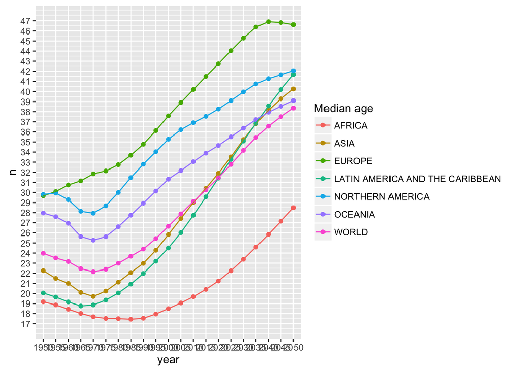

```r
subset_world <- subset(age_data_tidyr, `Median age` == "AFRICA" | `Median age` == "LATIN AMERICA AND THE CARIBBEAN" | `Median age` == "ASIA" | `Median age` == "EUROPE" | `Median age` == "NORTHERN AMERICA" | `Median age` == "OCEANIA" | `Median age` == "WORLD" )

qplot(x=year, y=n,
      data=subset_world,
      color = `Median age`,
      group = `Median age`,
      geom = c('point', 'line')) +
  scale_y_continuous(limits = c(17, 47), breaks =seq(17,47,1))
```

```r
ggsave('median_age_chart.png')
summary(subset_world)
```

```
##                            Median age     year                 n
##  AFRICA                         :21   Length:147         Min.   :17.44
##  ASIA                           :21   Class :character   1st Qu.:22.98
##  EUROPE                         :21   Mode  :character   Median :29.57
##  LATIN AMERICA AND THE CARIBBEAN:21                      Mean   :29.71
##  NORTHERN AMERICA               :21                      3rd Qu.:36.17
##  OCEANIA                        :21                      Max.   :46.90
##  (Other)                        :21
```

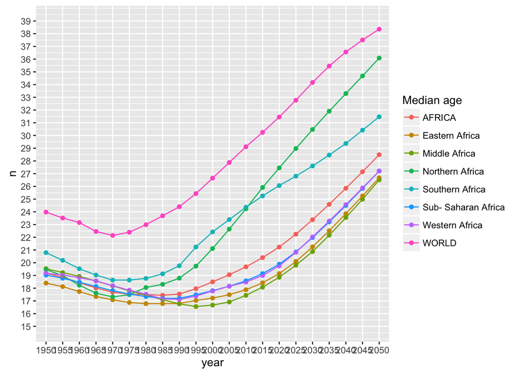

```r
subset_world2 <- subset(age_data_tidyr, `Median age` == "Eastern Africa" | `Median age` == "Western Africa" | `Median age` == "Middle Africa" | `Median age` == "Northern Africa" | `Median age` == "Southern Africa" | `Median age` == "Sub- Saharan Africa" | `Median age` == "AFRICA" | `Median age` == "WORLD" )

qplot(x=year, y=n,
      data=subset_world2,
      color = `Median age`,
      group = `Median age`,
      geom = c('point', 'line')) +
  scale_y_continuous(limits = c(15, 39), breaks =seq(15,39,1))
```

```r
ggsave('median_age_chart_africa.png')
summary(subset_world2)
```

```
##                Median age     year                 n
##  AFRICA             :21   Length:168         Min.   :16.56
##  Eastern Africa     :21   Class :character   1st Qu.:18.05
##  Middle Africa      :21   Mode  :character   Median :19.53
##  Northern Africa    :21                      Mean   :21.78
##  Southern Africa    :21                      3rd Qu.:24.42
##  Sub- Saharan Africa:21                      Max.   :38.36
##  (Other)            :42
```